# HW 6: Simple implementation of TMLE

Modern Methods for Causal Inference

Due July 13, 2020 at 3pm on Canvas

This homework will cover Targeted Minimum Loss-Based Estimation (TMLE) using *parametric* models (generalized linear models, as opposed to data adaptive methods). Next class you will begin implementing TMLE using data adaptive methods via SuperLearner.

Although we do not have a practice lab for this homework, you can [review a similar TMLE tutorial here](https://migariane.github.io/TMLE.nb.html#1_introduction).

# Background

Suppose you want to study the effect of steroid administration on critically ill COVID-19 patients. You will collect data on the following variables:

- `Y`: a 28 day mortality indicator
- `A`: binary treatment variable for steroids on first day of hypoxic state (hypoxic state defined as requiring greater than 6L of supplemental oxygen) (1: yes 0: no)
- `W1`: Gender (1 male; 0 female)
- `W2`: Age at hospitalization (in decades)
- `W3`: SOFA pulmonary organ failure score (scale of increasing severity from 1 to 4)
- `W4`: Number of relevant comorbidities (scale from 1 to 5) - Coronary Artery Disease, hypertension, Diabetes Mellitus, asthma, immunosuppressed state

**1. Set your seed to 7 and run the following data generating function to simulate `n=10,000` COVID-19 patients.**

```r
set.seed(7)
n = 10000
generateData <- function(n){
  w1 <- rbinom(n, size=1, prob=0.35)
  w2 <- rnorm(n, mean = 6, sd = 1)
  w3 <- round(runif(n, min=0, max=4), digits=3)
  w4 <- round(runif(n, min=0, max=5), digits=3)
  A  <- rbinom(n, size=1, prob= plogis(-0.8 + 0.3*w2 + 0.25*w3 + 0.2*w4 + 0.3*w2*w4))
  # counterfactual
  Y_1 <- rbinom(n, size=1, prob= plogis(-3 + 1 -0.2*w1 + 0.35*w2 + 0.15*w3 + 0.25*w4 + 0.1*w2*w4))
  Y_0 <- rbinom(n, size=1, prob= plogis(-3 + 0 -0.2*w1 + 0.35*w2 + 0.15*w3 + 0.25*w4 + 0.1*w2*w4))
  # Observed outcome
  Y <- Y_1*A + Y_0*(1 - A)
  # return data.frame
  data.frame(w1, w2, w3, w4, A, Y, Y_1, Y_0)
}
```

**2. Calculate *and interpret* the true value of $\theta = E[Y_1]-E[Y_0]$.**

```r
df1 = generateData(n)
theta = mean(df1$Y_1) - mean(df1$Y_0)
theta
```

```
## [1] 0.118
```

The expectation difference of a 28 day mortality status between patients received steroid administration, and those who do not receive it is 0.118.

# Simple TMLE Implementation

## Step 1: Estimate $m(A,W)$

Estimation of the initial probability of the outcome ($Y$) given the treatment ($A$) and the set of covariates ($W$), denoted as $m(A,W)$. To estimate $m(A,W)$ we can use a standard logistic regression model:

$m(A,W) = logit[P(Y=1|A,W)]=β0+β1A+β_2^TW$

**3. Fit the above `glm` and use the `predict` function to obtain the outputs of $m(A,W)$, $m(1,W)$, and $m(0,W)$.**

```r
Y <- df1$Y
Y1 <- df1$Y_1
Y0 <- df1$Y_0
A <- df1$A
w1 <- df1$w1
w2 <- df1$w2
w3 <- df1$w3
w4 <- df1$w4
m.model = glm(Y ~ A + w1 +w2 +w3 + w4, family = binomial(link = "logit"))
X0 = df1[which(df1$A == 0),1:5]
X1 = df1[which(df1$A == 1),1:5]
maw = predict(m.model)
m1w = predict(m.model, newdata = data.frame(A = 1, w1,w2,w3,w4))
m0w = predict(m.model, newdata = data.frame(A = 0, w1,w2,w3,w4))


pr.Y1 = plogis(m1w)
pr.Y0 = plogis(m0w)
data.m <- round(cbind(maw, m1w, m0w, Pr.Y1=pr.Y1,Pr.Y0=pr.Y0), digits= 3)
datatable(head(data.m, n = nrow(data.m)), options = list(pageLength = 5, digits = 3))
```

|  | maw | m1w | m0w | Pr.Y1 | Pr.Y0 |
| --- | --- | --- | --- | --- | --- |
| 1 | 1.85 | 1.85 | 0.786 | 0.864 | 0.687 |
| 2 | 1.437 | 1.437 | 0.372 | 0.808 | 0.592 |
| 3 | 2.069 | 2.069 | 1.005 | 0.888 | 0.732 |
| 4 | 1.773 | 1.773 | 0.709 | 0.855 | 0.67 |
| 5 | 3.785 | 3.785 | 2.72 | 0.978 | 0.938 |
| 6 | 1.168 | 1.168 | 0.104 | 0.763 | 0.526 |
| 7 | 3.438 | 3.438 | 2.374 | 0.969 | 0.915 |
| 8 | 4.85 | 4.85 | 3.785 | 0.992 | 0.978 |
| 9 | 2.199 | 2.199 | 1.135 | 0.9 | 0.757 |
| 10 | 3.532 | 3.532 | 2.468 | 0.972 | 0.922 |

[output cut: 9990 more lines]

**4. If you were to stop here and estimate the casual parameter $\theta = E[Y_1]-E[Y_0]$ using $\hat{\theta} = \hat{m}(1,W)-\hat{m}(0,W)$, what statistical estimation technique would this be? Implement this estimation technique for comparison with TMLE.**

```r
theta.hat = mean(pr.Y1 - pr.Y0)
theta.hat
```

```
## [1] 0.1334606
```

A simple substitution (G-computation) can be used to obtain the estimator. And this statistical estimation technique relies on $E(Y|A,W)$ and the covariate distribution $P(W)$. However, TMLE is a doubly robust estimator and does not only require $E(Y|A,W)$ or $P(W)$, but also asks for the exposure mechanism $P(A|W)$.

## Step 2: Estimate $g(W)$

Next we need of the probability of the treatment ($A$) given the set of covariates ($W$), denoted as $g(W)$. We can again use a logistic regression model for this simple implementation.

$g(W) = logit[P(A=1|W)]=\alpha_0+\alpha_1^TW$

**5. Fit the above `glm` and use the `predict` function to obtain the outputs of $g(W)$. Compute $P(A=1|W)$ and $P(A=0|W)$ for every patient in the simulated study and call these vectors `prob_A1_given_W` and `prob_A0_given_W`.**

```r
g = glm(A ~ w2 + w3 + w4, data = df1, family = binomial)
prob_A1_given_W = predict(g, type = "response")
prob_A0_given_W = 1-prob_A1_given_W
```

**6. Comment on the distributions of $\hat{g}(W)$ and $1-\hat{g}(W)$.**

```r
summary(prob_A1_given_W)
```

```
##    Min. 1st Qu.  Median    Mean 3rd Qu.    Max.
##  0.4248  0.9805  0.9978  0.9773  0.9998  1.0000
```

```r
summary(prob_A0_given_W)
```

```
##      Min.   1st Qu.    Median      Mean   3rd Qu.      Max.
## 0.0000048 0.0002359 0.0022012 0.0227000 0.0195386 0.5752234
```

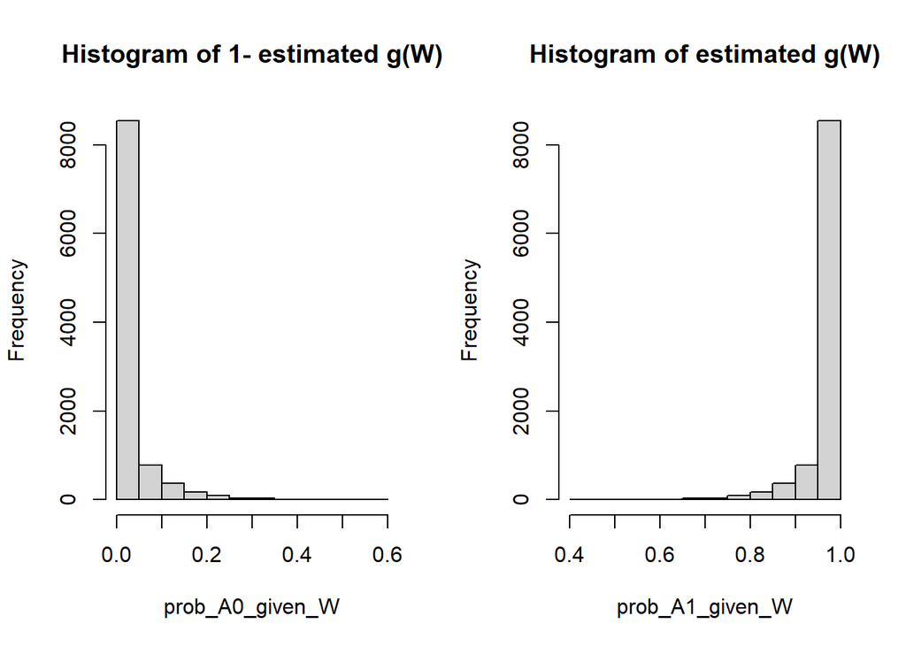

```r
par(mfrow = c(1,2))
hist(prob_A0_given_W, main = "Histogram of 1- estimated g(W)")
hist(prob_A1_given_W, main = "Histogram of estimated g(W)")
```

For $\hat{g}(w)$, the minimum value is 0.4248, and the maximum value is 1. The mean vlue of $\hat{g}(w)$ is 0.9773. For $1-\hat{g}(w)$, the minimum value is close to 0, and the maximum value is 0.575. The mean vlue of $1-\hat{g}(w)$ is 0.0227.

## Step 3: Estimate the clever covariate $H(A,W)$

**7. Use these estimates to create the clever covariate `H_AW`. Interpret the clever covariate for this particular background story.**

$$\hat{H}(A,W) = \left(\frac{\mathrm{I}(A=1)}{\hat{g}(W)} - \frac{\mathrm{I}(A=0)}{1-\hat{g}(W)} \right)$$

```r
H_AW = (A/prob_A1_given_W) - ((1-A)/prob_A0_given_W)
```

**8. Also evaluate the clever covariate at $A=1$ and $A=0$ for all patients. Call the resulting vectors `H_1W` and `H_0W`, respectively.**

```r
H_1W = 1/prob_A1_given_W
H_0W = -1/prob_A0_given_W
```

**9. What previously learned causal inference statistical estimation technique do you now have all the necessary information to complete? Implement this technique for comparison with TMLE.**

```r
AIPW <- mean((H_AW*(Y - plogis(maw)) + (plogis(m1w) - plogis(m0w))));AIPW
```

```
## [1] 0.1138054
```

We can calculate Augmented IPW, which can solve misspecification bias and allow computation of confidence intervals and p-values. However, TMLE provides the less unbiased ATE estimate compared with this double-robust estimator.

## Step 4: Target the initial estimator

*This is the crucial step of TMLE: updating the initial estimator of the conditional mean outcome $\hat{\mathrm{E}}(Y|A,W)$ with information in the estimated exposure mechanism $\hat{\mathrm{P}}(A=1|W)$.*

**10. Run a univariate regression of the outcome $Y$ on the clever covariate $\hat{H}(A,W)$ with the (logit of the) initial estimates as offset. Specifically, we estimate the coefficient $\epsilon$ by fitting the following logistic regression model:**
$$\begin{align*}
logit[m(A,W;\epsilon)] = logit[\hat{m}(A,W)] + \epsilon \hat{H}(A,W).
\end{align*}$$

*Note:* there is no intercept (i.e. there is no $\beta_0$ term), and the coefficient on the ($logit$ of the) initial estimator is set to 1.

```r
expY_givenAW = plogis(maw)
logit_update<- glm(Y ~ -1 + offset(qlogis(expY_givenAW)) + H_AW,
                  family='binomial')
```

**11. Let `epsilon` denote the resulting maximum likelihood estimate of the coefficient on the clever covariate `H_AW`.**

```r
epsilon = coef(logit_update);cat("\n Epsilon:",epsilon)
```

```
##
##  Epsilon: -0.001037171
```

**12. Update the initial estimate of $\hat{m}(A,W)$ according to the fluctuation model:**

$$\begin{align*}
logit[\hat{m}(A,W)] &= logit [\hat{m}(A,W)] + \hat{\epsilon} \hat{H}(A,W) \\
\tilde{m}(A,W) &= expit \bigg[ logit\big[ \hat{m}(A,W) \big] + \hat{\epsilon} \hat{H}(A,W) \bigg]
\end{align*}$$

```r
maw.update = plogis(maw + epsilon*H_AW)
```

**13. Plug-in the estimated coefficient $\hat{\epsilon}$ to yield targeted estimates of the expected outcome under the exposure $\tilde{m}(1,W)$ and under no exposure $\tilde{m}(0,W)$:**

$$\begin{align*}
\tilde{m}(1,W) &= expit \bigg[ logit\big[ \hat{m}(1,W) \big] + \hat{\epsilon} \hat{H}(1,W) \bigg]\\
\tilde{m}(0,W) &= expit \bigg[ logit\big[ \hat{m}(0,W) \big] + \hat{\epsilon} \hat{H}(0,W) \bigg]\\
\end{align*}$$

Recall $\hat{H}(1,W)$ is the clever covariate evaluated for all units under the exposure, and $\hat{H}(0,W)$ is the clever covariate evaluated for all units under no exposure.

```r
m0w.update = plogis(m0w + epsilon*H_0W)
m1w.update = plogis(m1w + epsilon*H_1W)
```

**14. Estimate and interpret $\theta = E[Y_1]-E[Y_0]$ using TMLE. Compare it with the true value, and your estimates in the previous questions.**

```r
theta.update = mean(m1w.update - m0w.update);cat("\n Theta:",theta.update)
```

```
##
##  Theta: 0.08620371
```

```r
AIPW <- mean((H_AW*(Y - plogis(maw)) + (plogis(m1w) - plogis(m0w))));AIPW
```

```
## [1] 0.1138054
```

```r
cat("\n TMLE bias:", abs(theta-theta.update))
```

```
##
##  TMLE bias: 0.03179629
```

```r
cat("\n Estimated theta bias:", abs(theta-theta.hat))
```

```
##
##  Estimated theta bias: 0.0154606
```

The true value of $\theta$ is 0.118, and the TMLE estimand is 0.086. The G-Computation of $\theta$ is 0.133. And the AIPW estimator of $\theta$ is 0.114. The bias of TMLE is 0.032 which is higher than the bias of estimated theta(0.015).

# Inference

**15. How can we obtain standard errors for TMLE? How does this compare to G-Computation, IPTW, and Augmented IPW?**

If both of $\hat g$ and $\hat m$ are consistent for g and m, respectively, $\hat \theta_{tmle}$ is asymptotically linear: $\hat \theta_{tmle} - \theta = \frac{1}{n}\displaystyle\sum_{i = 1}^nD_P(O_i)$.

We can have $\sqrt n(\hat\theta_{tmle} - \theta) \rightarrow N(0,\sigma^2)$. And $\sigma^2 = Var D_p(O)$.

Then we can calculate $D_{\hat P}(O_i)$ for each subject, $D_{\hat P}(O_i) = \frac{A_i}{\hat g(W_i)}[Y_i - \widetilde m(W_i)]+\widetilde m(W_i) - \hat\theta_{tmle}$ and calculate the empitical variance.

The errors for G-Computaiton estimand and IPTW can be obtained by calculating the variance in the data set. The errors for TMLE and AIPW can be obtained through calculating the $D_{p}(O)$.

```r
n <- nrow(df1)
# G-Computation
cat("\n se of G-Computation:", sqrt(var(pr.Y1-pr.Y0)/n))
```

```
##
##  se of G-Computation: 0.000827047
```

```r
# AIPW
cat("\n se of AIPW:", sqrt(var(H_AW*(Y-plogis(maw)) + (pr.Y1-pr.Y0) - AIPW)/n))
```

```
##
##  se of AIPW: 0.03389798
```

```r
# TMLE
var_tmle <- var(H_AW * (Y - maw.update) + (m1w.update-m0w.update) - theta.update)/n
sd_tmle <- sqrt(var_tmle)
cat("\n se of TMLE:", sd_tmle)
```

```
##
##  se of TMLE: 0.03070155
```

The standard error of TMLE estimand is 0.031, which is greater than the error for G-Computation. And the error for TMLE is less than AIPW estimand. Therefore, based on standard error, the TMLE performance is better than AIPW, while worse than G-Computation.

**16. What limitations do you see in estimating $g(W)$ and $m(A,W)$ using logistic regressions?**

In estimating process using logistic regression, the assumption for the relationship of logit(A) or logit(Y) and covariates is linear without the consideration of interaction among covariates and the transformation form of them. Therefore, we can use superlearner or cv.superlearner to obtain a better estimation.